# 시각화

hyo

2020 4 5

##### 문제1

- x변수에 -1부터 1까지 100개의 데이터 저장
- y변수에 x변수를 지수화한 데이터 저장
- main title을 “y=exp(x)”로 y label을 exp(x)로 출력하시오
- 점선으로 표시 하되 색은 orange로 표시

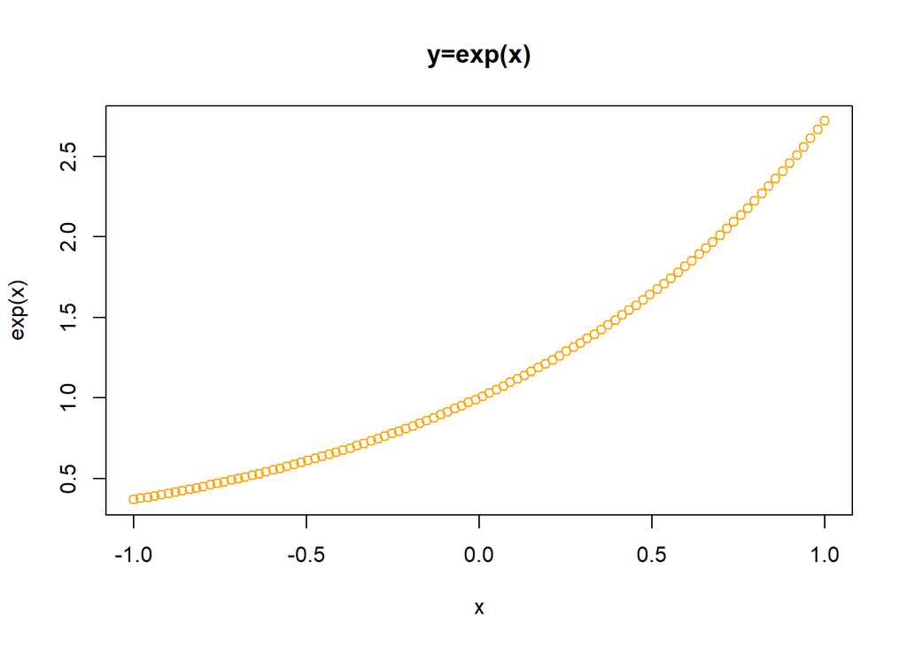

```r
x = seq(-1,1,length=100)
y = exp(x)
plot(x,y,
     main = "y=exp(x)",
     ylab = "exp(x)",
     lty = "dotted",
     col = "orange"
     )
```

##### 문제2

- FCX.csv 파일을 읽은 후 Adj_Close 변수를 선택하여 baxplot과 histogram을 그리시오
  - 두개의 plot이 동시에 나오게끔 코드를 작성하시오 (왼쪽 histogram, 오른쪽 boxplot)

```r
library(readr)
setwd("C:/Users/haley/Desktop/haley/task/Rbasic/statistic_lecture/시각화")
FCX = read_csv("FCX.csv")
```

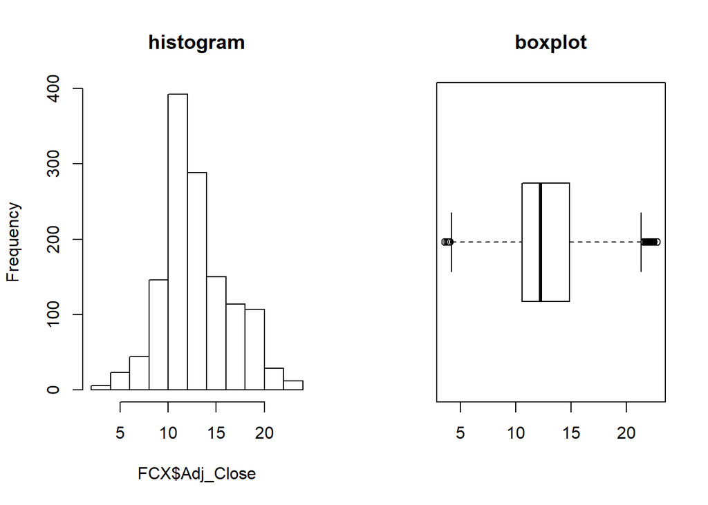

```r
par(mfrow=c(1,2))
hist(FCX$Adj_Close,main="histogram")
boxplot(FCX$Adj_Close,
        main="boxplot",horizontal=TRUE)
```

##### 문제3

- 문제2의 histogram을 ggplot을 활용하여 그리시오 binwidth = 1로 설정하고 red로 색을 지정하시오
  - main title은 “histogram”으로 지정

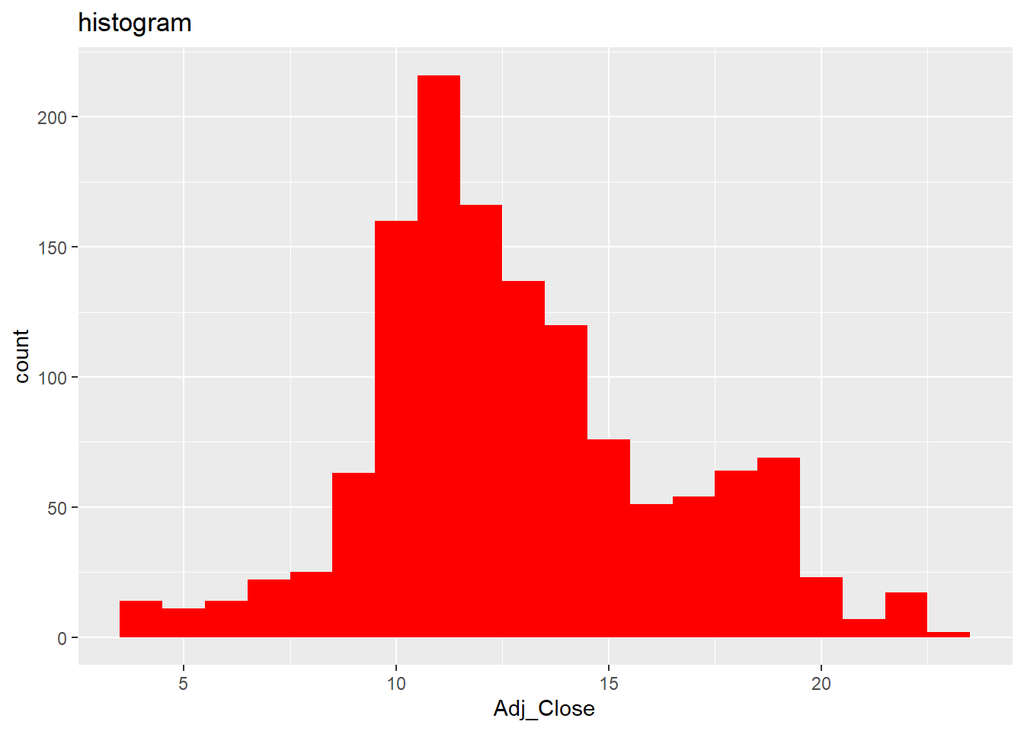

```r
library(ggplot2)
ggplot(FCX,
       aes(x = Adj_Close)) +
  geom_histogram(binwidth = 1, fill = "red") +
  ggtitle("histogram")
```

##### 문제4

- ggplot에 있는 diamond 데이터 확인
- 변수 cut(품질)에 따라 자료를 그룹으로 나누어 그룹별 boxplot을 하나의 그림에 겹쳐서 그려보시오
- 이상값을 green 색깔로 표현

```r
library(tidyr)
library(ggplot2)
data("diamonds", package = "ggplot2")  # load the data
head(diamonds)
```

```
## # A tibble: 6 x 10
##   carat cut       color clarity depth table price     x     y     z
##   <dbl> <ord>     <ord> <ord>   <dbl> <dbl> <int> <dbl> <dbl> <dbl>
## 1 0.23  Ideal     E     SI2      61.5    55   326  3.95  3.98  2.43
## 2 0.21  Premium   E     SI1      59.8    61   326  3.89  3.84  2.31
## 3 0.23  Good      E     VS1      56.9    65   327  4.05  4.07  2.31
## 4 0.290 Premium   I     VS2      62.4    58   334  4.2   4.23  2.63
## 5 0.31  Good      J     SI2      63.3    58   335  4.34  4.35  2.75
## 6 0.24  Very Good J     VVS2     62.8    57   336  3.94  3.96  2.48
```

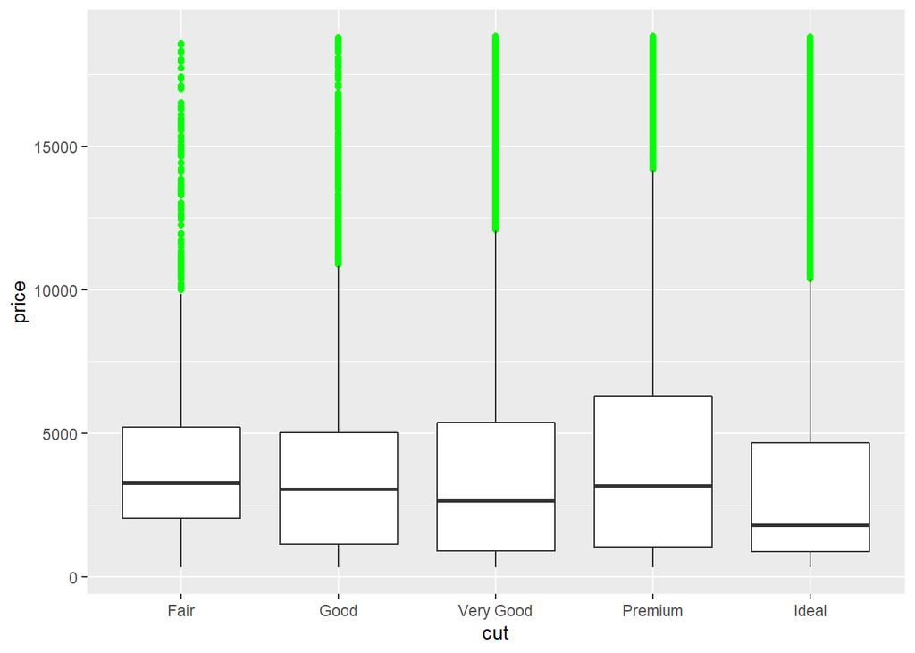

```r
ggplot(diamonds,
       aes(cut,price)) +
  geom_boxplot(outlier.colour = "green")
```

##### 문제5

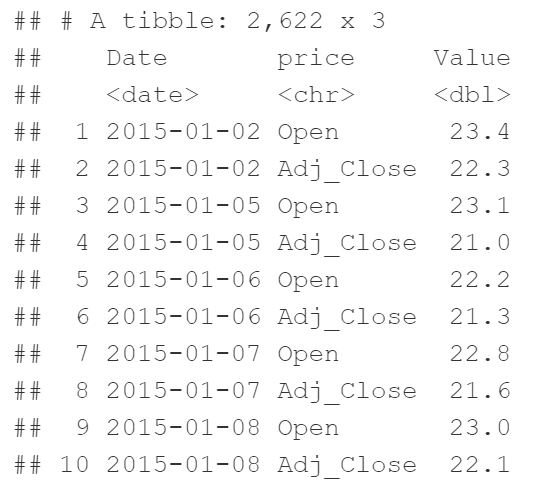

- FCX 데이터를 위 표와 같이 형태를 바꾸어준다
  - Date, Open, Adi_Close 선택
  - 위 표 같이 pivot_longer을 사용하여 데이터 처리
- 날짜변수를 x, Value를 그룹으로 하여 price를 시각화 하시오

```r
library(tidyr)
library(dplyr)
```

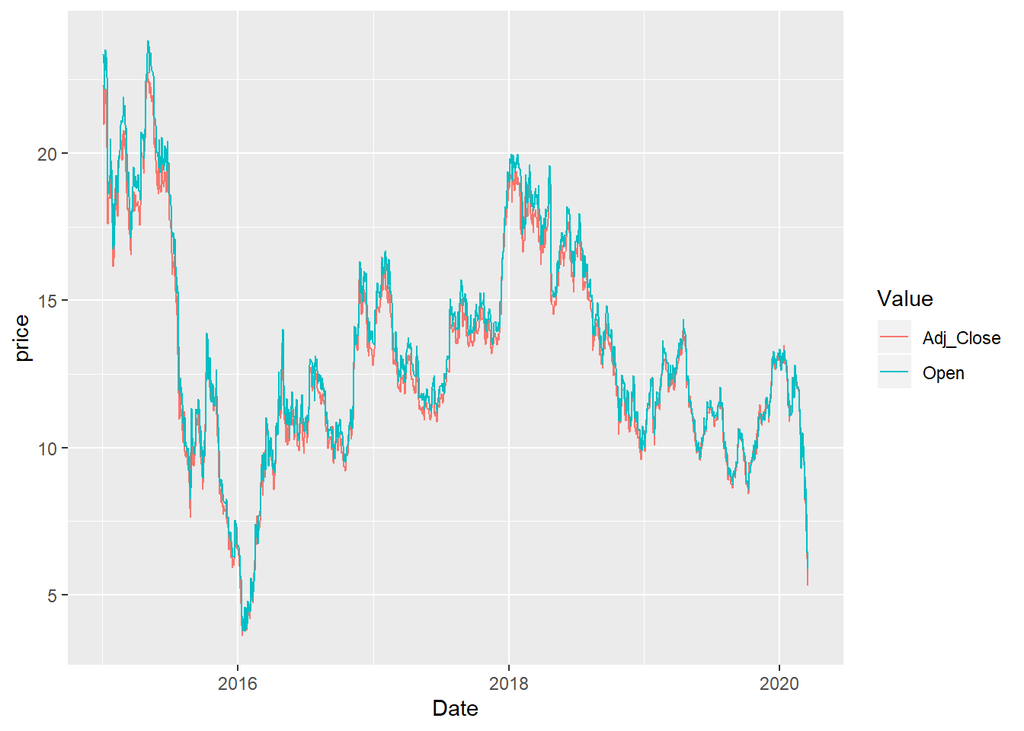

```r
library(stringr)
FCX %>%
  select(Date,Open,Adj_Close) %>%
  pivot_longer(cols = -Date, names_to = 'Value', values_to = 'price') %>%
  ggplot(aes(x = Date, y = price, group = Value)) +
  geom_line(aes(color = Value))
```

##### 문제6

- 위 그림을 line과 함께 point를 같이 접목시켜 시각화 해보시오

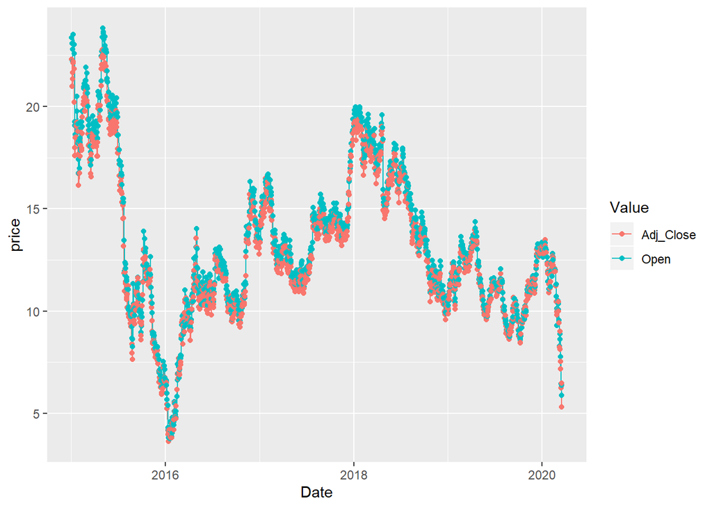

```r
FCX %>%
  select(Date,Open,Adj_Close) %>%
  pivot_longer(cols = -Date, names_to = 'Value', values_to = 'price') %>%
  ggplot(aes(x = Date, y = price, group = Value)) +
  geom_line(aes(color = Value)) + geom_point(aes(color = Value))
```

##### 문제7

- 위 그림을 각각의 그림으로 나누어 그리시오
  - `facet_grid()` 혹은 `facet_wrap()` 함수 사용

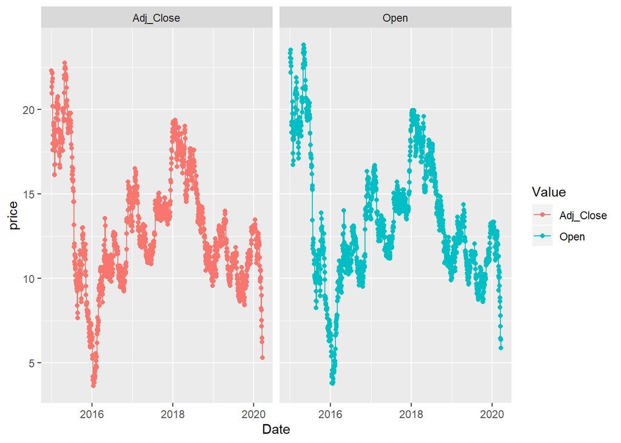

```r
FCX %>%
  select(Date,Open,Adj_Close) %>%
  pivot_longer(cols = -Date, names_to = 'Value', values_to = 'price') %>%
  ggplot(aes(x = Date, y = price, group = Value)) +
  geom_line(aes(color = Value)) +
  facet_grid(~ Value) +
  geom_point(aes(color = Value))
```

##### 문제8

- FCX의 Open 가격의 히스토그램을 그린 뒤 정규분포인지 여부를 확인 해보시오
  - 히스토그램의 색은 blue로 채우기
  - density의 값은 default

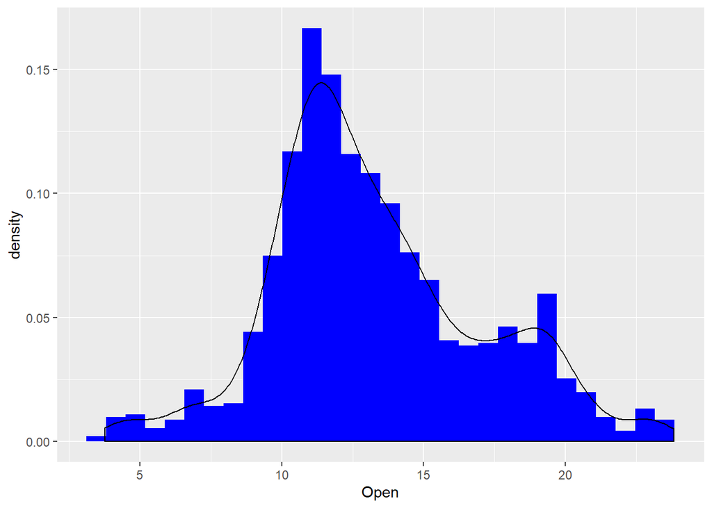

```r
FCX %>%
  select(Date, Open) %>%
  ggplot(aes(x = Open)) +
  geom_histogram(aes(y = ..density..), fill = 'blue') +
  geom_density()
```

##### 문제9

- FCX의 Date변수를 year month day로 분리
  - Adj_Close의 월별 최댓값을 계산하여 Max_Adj_Close에 저장
  - 막대그래프로 표현
  - Max_Adj_Close가 평균보다 작으면 red, 크거나 같으면 blue로 표시

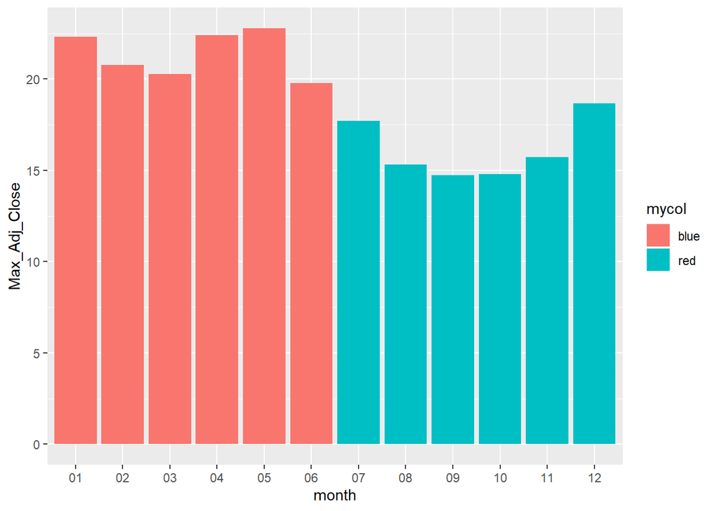

```r
FCX %>%
  select(Date, Adj_Close) %>%
  separate(Date, c('year', 'month','day'),sep = "-") %>%
  group_by(month) %>%
  summarize(Max_Adj_Close = max(Adj_Close)) %>%
  mutate(mycol = ifelse(Max_Adj_Close < mean(Max_Adj_Close), 'red', 'blue')) %>%
  ggplot(aes(x = month, y = Max_Adj_Close)) +
  geom_col(aes(fill = mycol))
```

##### 문제10

- FCX 데이터 중 Volume를 제외한 모든 변수들의 boxplot을 ggplot을 이용하여 그리시오

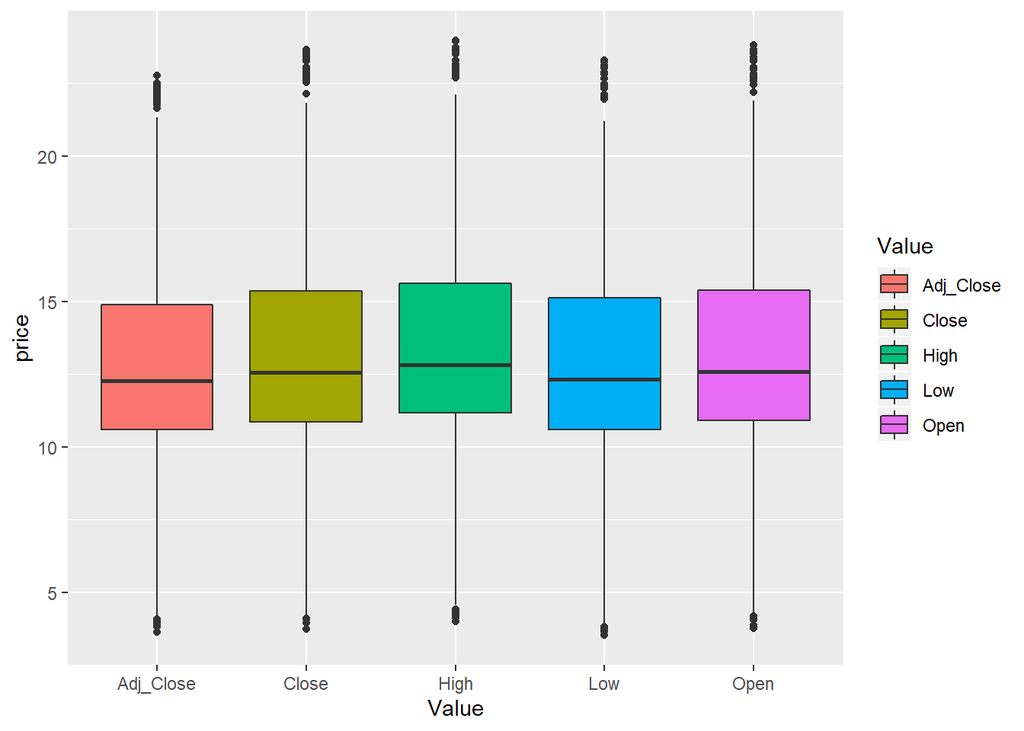

```r
FCX %>%
  select(-Volume) %>%
  pivot_longer(cols = -Date, names_to = 'Value', values_to = 'price') %>%
  ggplot(aes(x = Value, y = price, group = Value)) +
  geom_boxplot(aes(fill = Value))
```